# STEAMPY User's Guide

Chuyu Dai

## Section 1. How to download and set up

```python
%load_ext autoreload
%autoreload 2
```

```python
from steampy import OctoFetch
```

Set up your API key obtained from steamapis.

*Notice here the provided API is a key for grading purpose*

```python
myAPI = "7oV5S3zAF_S4rFkz1_RGhitSYT4"
octoFetch = OctoFetch(api_key = myAPI)
```

## Section 2. Functionality explained

## `API_coverage()`

This function visualize up-to-date API coverage of total steam games and items, and how much people spent on steam on total.

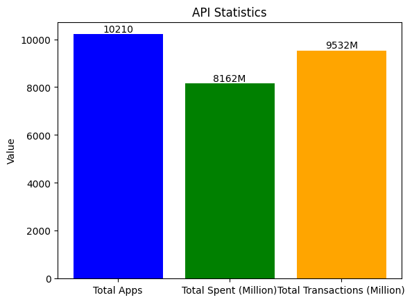

```python
octoFetch.API_coverage()
```

## `fetch_profile`

This function allows steampy users to fetch user's profile information including name, online status, games being played, avatar and more by using the user's steam_id.

```python
octoFetch.fetch_profile(steam_id=76561198206423576)
```

|  | name | onlineState | stateMessage | privacyState | visibilityState | avatarHash | vacBanned | tradeBanState | isLimitedAccount | customURL | ... | contexts.753.link | contexts.753.asset_count | contexts.753.inventory_logo | contexts.753.trade_permissions | contexts.753.load_failed | contexts.753.store_vetted | contexts.753.owner_only | contexts.753.rgContexts.6.asset_count | contexts.753.rgContexts.6.id | contexts.753.rgContexts.6.name |
| --- | --- | --- | --- | --- | --- | --- | --- | --- | --- | --- | --- | --- | --- | --- | --- | --- | --- | --- | --- | --- | --- |
| 0 | RicoX | offline | Offline | public | 3 | e3119c95146344c4d410dfb0038a898a9361dbb1 | False | None | False | RicoX234 | ... | https://steamcommunity.com/app/753 | 164 | https://cdn.akamai.steamstatic.com/steamcommun... | FULL | 0 | 1 | False | 164 | 6 | Community |

1 rows × 49 columns

## `fetch_inventory`

```python
octoFetch.fetch_inventory(steam_id=76561198038526790, app_id=730, context_id=2)
```

|  | assets | total_inventory_count |
| --- | --- | --- |
| 0 | [{'appid': 730, 'contextid': '2', 'assetid': '... | 727 |

## `app_info`

This function retrieves detailed information for required games including price, developer, category, description and more.

User can either specify a single app_id or a list of app_ids to conduct the search.

There is also a `report` option that will generate a report sytle search result instead of the dataframe.

```python
# using app_ids
octoFetch.app_info(app_ids=[250700,730])
```

|  | appID | type | name | is_free | header_image | background | developers | publishers | detailed_description | short_description | ... | price_overview.discount_percent | price_overview.final | price_overview.initial | price_overview.currency | platforms.linux | platforms.mac | platforms.windows | recommendations.total | release_date.date | release_date.coming_soon |
| --- | --- | --- | --- | --- | --- | --- | --- | --- | --- | --- | --- | --- | --- | --- | --- | --- | --- | --- | --- | --- | --- |
| 0 | 250700 | game | Super Time Force Ultra | False | https://steamcdn-a.akamaihd.net/steam/apps/250... | https://steamcdn-a.akamaihd.net/steam/apps/250... | [Capybara Games] | [Capybara Games] | <strong>Super Time Force Ultra</strong> is an ... | Super Time Force Ultra is an insane platformer... | ... | 0 | 1499 | 1499 | USD | True | True | True | 571 | Aug 25, 2014 | False |
| 1 | 730 | game | Counter-Strike: Global Offensive | True | https://steamcdn-a.akamaihd.net/steam/apps/730... | https://steamcdn-a.akamaihd.net/steam/apps/730... | [Valve, Hidden Path Entertainment] | [Valve] | Counter-Strike: Global Offensive (CS: GO) expa... | Counter-Strike: Global Offensive (CS: GO) expa... | ... | 0 | 1499 | 1499 | USD | True | True | True | 2850475 | Aug 21, 2012 | False |

2 rows × 28 columns

```python
# generate report
octoFetch.app_info(app_ids=[250700,491950], report=True)
```

```
0. 'Super Time Force Ultra' was released on Aug 25, 2014. The game was developed by ['Capybara Games'] and published by ['Capybara Games'].

 Description of the game: Super Time Force Ultra is an insane platformer filled with robots and dinosaurs and fun and time travel... sometimes all at the same time!.

 Super Time Force Ultra is recommended by 571 people.

 The game costs 14.99 USD.

 It is available on Linux, Mac, Windows.

1. 'Orwell: Keeping an Eye On You' was released on Oct 27, 2016. The game was developed by ['Osmotic Studios'] and published by ['Fellow Traveller'].

 Description of the game: Big Brother has arrived - and it’s you. Investigate the lives of citizens to find those responsible for a series of terror attacks. Information from the internet, personal communications and private files are all accessible to you. But, be warned, the information you supply…

 Orwell: Keeping an Eye On You is recommended by 6227 people.

 The game costs 9.99 USD.

 It is available on Linux, Mac, Windows.
```

|  | appID | type | name | is_free | header_image | background | developers | publishers | detailed_description | short_description | ... | price_overview.discount_percent | price_overview.final | price_overview.initial | price_overview.currency | platforms.linux | platforms.mac | platforms.windows | recommendations.total | release_date.date | release_date.coming_soon |
| --- | --- | --- | --- | --- | --- | --- | --- | --- | --- | --- | --- | --- | --- | --- | --- | --- | --- | --- | --- | --- | --- |
| 0 | 250700 | game | Super Time Force Ultra | False | https://steamcdn-a.akamaihd.net/steam/apps/250... | https://steamcdn-a.akamaihd.net/steam/apps/250... | [Capybara Games] | [Capybara Games] | <strong>Super Time Force Ultra</strong> is an ... | Super Time Force Ultra is an insane platformer... | ... | 0 | 1499 | 1499 | USD | True | True | True | 571 | Aug 25, 2014 | False |
| 1 | 491950 | game | Orwell: Keeping an Eye On You | False | https://steamcdn-a.akamaihd.net/steam/apps/491... | https://steamcdn-a.akamaihd.net/steam/apps/491... | [Osmotic Studios] | [Fellow Traveller] | <h1>Season 2, Orwell Ignorance is Strength is ... | Big Brother has arrived - and it’s you. Invest... | ... | 0 | 999 | 999 | USD | True | True | True | 6227 | Oct 27, 2016 | False |

2 rows × 28 columns

## `ambi_search_game`

This function utilizes **regular expression** to allow users to do AMBIGUOUS SEARCH when they can only remember partially the name of a game. This function will then supply all matched games' information.

The function has three styling options avaible for users by specifying the `style` parameter.

The default setting is `style = "basic"`, and this will return a most basic dataframe containing only appID, game name and price information.

```python
octoFetch.ambi_search_game("orw")
```

|  | appID | name | discount_percent | final | initial | currency |
| --- | --- | --- | --- | --- | --- | --- |
| 0 | 383930 | Doorways: Holy Mountains of Flesh | 0 | $19.99 |  | USD |
| 1 | 311250 | Doorways: The Underworld | 0 | $9.99 |  | USD |
| 2 | 375030 | Korwin The Game | 0 | $1.99 |  | USD |
| 3 | 248470 | Doorways: Prelude | 0 | $9.99 |  | USD |
| 4 | 629410 | VectorWave | 0 | $4.99 |  | USD |
| 5 | 491950 | Orwell: Keeping an Eye On You | 0 | $9.99 |  | USD |
| 6 | 333250 | Forward to the Sky | 0 | $7.99 |  | USD |
| 7 | 600350 | VectorWars VR | 0 | $2.99 |  | USD |
| 8 | 633060 | Orwell: Ignorance is Strength | 0 | $9.99 |  | USD |
| 9 | 696480 | The Norwood Suite | 0 | $9.99 |  | USD |

However, since we know that when users only remeber part of the game name, sometimes they only remeber what the name is about, so even if we return the name and price information, users may still not recognize which game they are looking for.

Therefore, this function also allows for `style = "detail"`, that includes more information.

```python
octoFetch.ambi_search_game("portal",style= "detailed")
```

|  | appID | type | name | is_free | header_image | background | developers | publishers | detailed_description | short_description | ... | price_overview.discount_percent | price_overview.final | price_overview.initial | price_overview.currency | platforms.linux | platforms.mac | platforms.windows | recommendations.total | release_date.date | release_date.coming_soon |
| --- | --- | --- | --- | --- | --- | --- | --- | --- | --- | --- | --- | --- | --- | --- | --- | --- | --- | --- | --- | --- | --- |
| 0 | 620 | game | Portal 2 | False | https://steamcdn-a.akamaihd.net/steam/apps/620... | https://steamcdn-a.akamaihd.net/steam/apps/620... | [Valve] | [Valve] | Portal 2 draws from the award-winning formula ... | The &quot;Perpetual Testing Initiative&quot; h... | ... | 0 | 999 | 999 | USD | True | True | True | 163781.0 | Apr 18, 2011 | False |
| 1 | 361850 | game | Portal of Evil: Stolen Runes Collector's Edition | False | https://steamcdn-a.akamaihd.net/steam/apps/361... | https://steamcdn-a.akamaihd.net/steam/apps/361... | [8Floor] | [8Floor] | The gates to another world will open soon! You... | The gates to another world will open soon! You... | ... | 0 | 499 | 499 | USD | False | False | True | 172.0 | May 26, 2015 | False |
| 2 | 700740 | game | Teenage Mutant Ninja Turtles: Portal Power | False | https://steamcdn-a.akamaihd.net/steam/apps/700... | https://steamcdn-a.akamaihd.net/steam/apps/700... | [Nickelodeon] | [Nickelodeon] | It’s a wild chase through space and time as th... | Shredder and the Kraang have spread chaos and ... | ... | 0 | 999 | 999 | USD | False | True | True | NaN | Dec 14, 2017 | False |
| 3 | 684410 | game | Bridge Constructor Portal | False | https://steamcdn-a.akamaihd.net/steam/apps/684... | https://steamcdn-a.akamaihd.net/steam/apps/684... | [ClockStone] | [Headup, Whisper Games] | <h1>Bridge Constructor Portal on Discord</h1><... | Enter the Aperture Science Enrichment Center a... | ... | 0 | 999 | 999 | USD | True | True | True | 2548.0 | Dec 20, 2017 | False |

4 rows × 28 columns

For better accessibility, a `style = "report"` parameter will return a report style paragraph for each matched game.

```python
octoFetch.ambi_search_game("behold",style= "report")
```

```
0. 'Beholder' matched the condition and was released on Nov 9, 2016. The game was developed by ['Warm Lamp Games'] and published by ['Alawar Premium'].

 Description of the game: You’re a state-installed landlord in a totalitarian country. Place listening devices, steal and sneak into your tenants’ apartments. Use what you uncovered to report anyone capable of plotting against the state. You MUST! But WILL you?.

 Beholder is recommended by 12503 number of people. The game costs 9.99USD.

  It is available on Linux, Mac, Windows.

1. 'Beholder 2' matched the condition and was released on Dec 4, 2018. The game was developed by ['Warm Lamp Games'] and published by ['Alawar Premium'].

 Description of the game: You are an intern at the central ministry of a totalitarian state with your whole career ahead of you. Work your way up the ladder by scheming against employees, spying on your boss, and completing paperwork. Or do you turn against the state and expose corruption. The choic…

 Beholder 2 is recommended by 2830 number of people. The game costs 14.99USD.

  It is available on Linux, Mac, Windows.
```

|  | appID | name | discount_percent | final | initial | currency |
| --- | --- | --- | --- | --- | --- | --- |
| 0 | 475550 | Beholder | 0 | $9.99 |  | USD |
| 1 | 761620 | Beholder 2 | 0 | $14.99 |  | USD |

## `top_n_discounted_game`

This function retrieves information for top n discounted games on Steam. The function has a `detailed` option if user want more detail of the games on discount.

```python
octoFetch.top_n_discounted_game(10,detailed = False)
```

|  | appID | name | discount_percent | final | initial | currency |
| --- | --- | --- | --- | --- | --- | --- |
| 3335 | 220740 | Chaos on Deponia | 90 | $1.99 | $19.99 | USD |
| 5139 | 298830 | Millennium 3 - Cry Wolf | 90 | $0.79 | $7.99 | USD |
| 4910 | 357070 | UBERMOSH | 90 | $0.49 | $4.99 | USD |
| 5176 | 217140 | Rise of the Triad | 90 | $1.49 | $14.99 | USD |
| 4811 | 241910 | Goodbye Deponia | 90 | $1.99 | $19.99 | USD |
| 908 | 223470 | POSTAL 2 | 90 | $0.99 | $9.99 | USD |
| 5311 | 454150 | Voxel Warfare Online | 90 | $0.49 | $4.99 | USD |
| 5363 | 423550 | Day D: Tower Rush | 90 | $0.49 | $4.99 | USD |
| 5365 | 283000 | Strategic War in Europe | 90 | $1.49 | $14.99 | USD |
| 5087 | 468930 | Phantaruk | 90 | $0.49 | $4.99 | USD |

```python
octoFetch.top_n_discounted_game(5,detailed = True)
```

|  | appID | type | name | is_free | header_image | background | developers | publishers | detailed_description | short_description | ... | price_overview.discount_percent | price_overview.final | price_overview.initial | price_overview.currency | platforms.linux | platforms.mac | platforms.windows | recommendations.total | release_date.date | release_date.coming_soon |
| --- | --- | --- | --- | --- | --- | --- | --- | --- | --- | --- | --- | --- | --- | --- | --- | --- | --- | --- | --- | --- | --- |
| 0 | 220740 | game | Chaos on Deponia | False | https://steamcdn-a.akamaihd.net/steam/apps/220... | https://steamcdn-a.akamaihd.net/steam/apps/220... | [Daedalic Entertainment] | [Daedalic Entertainment] | <h1>The Deponia series on Steam:</h1><p><a hre... | With this long-expected sequel to the critical... | ... | 90 | 199 | 1999 | USD | True | True | True | 1490.0 | Nov 6, 2012 | False |
| 1 | 298830 | game | Millennium 3 - Cry Wolf | False | https://steamcdn-a.akamaihd.net/steam/apps/298... | https://steamcdn-a.akamaihd.net/steam/apps/298... | [Aldorlea Games] | [Aldorlea Games] | <h2 class="bb_tag">Backstory</h2><br>Marine an... | Time is running out for Marine and her friends... | ... | 90 | 79 | 799 | USD | False | False | True | NaN | Aug 29, 2014 | False |
| 2 | 357070 | game | UBERMOSH | False | https://steamcdn-a.akamaihd.net/steam/apps/357... | https://steamcdn-a.akamaihd.net/steam/apps/357... | [Walter Machado] | [Walter Machado] | &quot;UBERMOSH is an arcade game about cutting... | UBERMOSH is an arcade game about cutting bulle... | ... | 90 | 49 | 499 | USD | True | False | True | 2021.0 | Aug 13, 2015 | False |
| 3 | 217140 | game | Rise of the Triad | False | https://steamcdn-a.akamaihd.net/steam/apps/217... | https://steamcdn-a.akamaihd.net/steam/apps/217... | [Interceptor Entertainment] | [Apogee Software] | Apogee Software and Interceptor Entertainment ... | Apogee Software and Interceptor Entertainment ... | ... | 90 | 149 | 1499 | USD | False | False | True | 1613.0 | Jul 31, 2013 | False |
| 4 | 241910 | game | Goodbye Deponia | False | https://steamcdn-a.akamaihd.net/steam/apps/241... | https://steamcdn-a.akamaihd.net/steam/apps/241... | [Daedalic Entertainment] | [Daedalic Entertainment] | <h1>The Deponia series on Steam:</h1><p><a hre... | More chaos, more destruction, more Rufus. Not ... | ... | 90 | 199 | 1999 | USD | True | True | True | 1351.0 | Oct 17, 2013 | False |

5 rows × 28 columns

## `free_game`

```python
octoFetch.free_game().head(5)
```

|  | appID | name |
| --- | --- | --- |
| 0 | 256410 | Might & Magic: Duel of Champions |
| 1 | 509860 | Baezult |
| 3 | 339000 | Ukrainian Ninja |
| 4 | 444090 | Paladins® |
| 5 | 216150 | MapleStory |

Since the `free_game` function returns a dataframe, user's can feel free to combine it with previous functinon to retrive more information or to generate report.

```python
free = octoFetch.free_game().head(3)
octoFetch.app_info(free['appID'], report = True)
```

```
0. 'Might & Magic: Duel of Champions' was released on Nov 7, 2013. The game was developed by ['Blue Byte'] and published by ['Ubisoft'].

 Description of the game: Enter the legendary universe of Might &amp; Magic with this fantastic strategic online card game. With more than 770 cards, choose your hero, build an army with creatures, spells, buildings and fortunes and defeat cunning opponents in battles of epic proportions..

 Might & Magic: Duel of Champions is recommended by 3642.0 people.

 The game costs nan nan.

 It is available on, Windows.

1. 'Baezult' was released on Aug 3, 2016. The game was developed by ['Atapki'] and published by ['Atapki'].

 Description of the game: Baezult is a puzzle/action platformer set in a lost temple hidden for thousands of years behind a waterfall. You play as a brave explorer looking to find riches beyond his wildest dreams. But be careful, the people of the temple have protected their wealth very well..

 Baezult is recommended by nan people.

 The game costs nan nan.

 It is available on, Windows.

2. 'Ukrainian Ninja' was released on Dec 23, 2014. The game was developed by ['Michael Kissinger', 'Marco Hulden', 'Shaun Egan', 'Joshua Marks', 'Denys Ovsiannykov'] and published by ['Dragon Fire Games Inc'].

 Description of the game: Ukrainian Ninja is a multiplayer platformer game for Windows. The Ninja shoots and slashes, using weapons sold by the trader to clear each world..

 Ukrainian Ninja is recommended by 188.0 people.

 The game costs 1.99 USD.

 It is available on, Windows.
```

|  | appID | type | name | is_free | header_image | background | developers | publishers | detailed_description | short_description | ... | platforms.linux | platforms.mac | platforms.windows | recommendations.total | release_date.date | release_date.coming_soon | price_overview.discount_percent | price_overview.final | price_overview.initial | price_overview.currency |
| --- | --- | --- | --- | --- | --- | --- | --- | --- | --- | --- | --- | --- | --- | --- | --- | --- | --- | --- | --- | --- | --- |
| 0 | 256410 | advertising | Might & Magic: Duel of Champions | True | https://steamcdn-a.akamaihd.net/steam/apps/256... | https://steamcdn-a.akamaihd.net/steam/apps/256... | [Blue Byte] | [Ubisoft] | Enter the legendary universe of Might &amp; Ma... | Enter the legendary universe of Might &amp; Ma... | ... | False | False | True | 3642.0 | Nov 7, 2013 | False | NaN | NaN | NaN | NaN |
| 1 | 509860 | game | Baezult | True | https://steamcdn-a.akamaihd.net/steam/apps/509... | https://steamcdn-a.akamaihd.net/steam/apps/509... | [Atapki] | [Atapki] | Baezult is a puzzle/action platformer set in a... | Baezult is a puzzle/action platformer set in a... | ... | False | False | True | NaN | Aug 3, 2016 | False | NaN | NaN | NaN | NaN |
| 2 | 339000 | game | Ukrainian Ninja | True | https://steamcdn-a.akamaihd.net/steam/apps/339... | https://steamcdn-a.akamaihd.net/steam/apps/339... | [Michael Kissinger, Marco Hulden, Shaun Egan, ... | [Dragon Fire Games Inc] | Ukrainian Ninja is a multiplayer platformer ga... | Ukrainian Ninja is a multiplayer platformer ga... | ... | False | False | True | 188.0 | Dec 23, 2014 | False | 0.0 | 199.0 | 199.0 | USD |

3 rows × 26 columns